[figure not shown]

AFRICAST

Tidy time series & forecasting in R

# Basic modelling and forecasting

Session 4 of 10

[figure not shown]

[figure not shown]

[figure not shown]

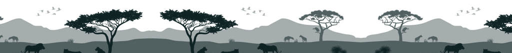

workshop.f4sg.org/africastForecasting for Social Good

## Outline

- Statistical forecasting
- What can we forecast?
- Benchmark methods
- Specify and estimate
- Produce forecasts
- Fitted values and residuals

## Your forecasting

What do you forecast (or wish you could) in your work?

# Statistical forecasting

## Forecasting workflow

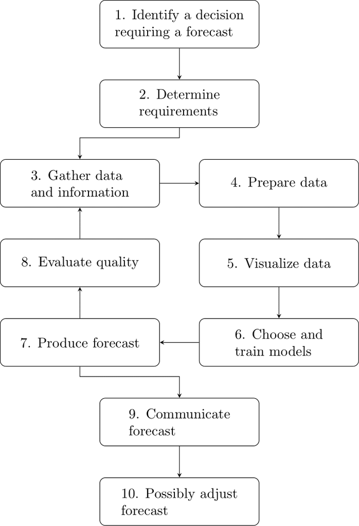

## Statistical forecasting steps

[figure not shown]

## What is a forecast?

A forecast is an estimate of the probability distribution of a variable to be observed in the future.

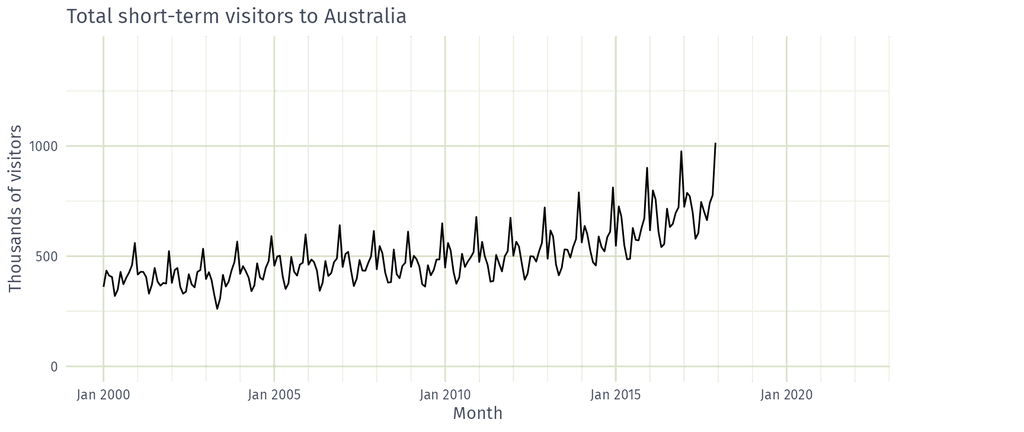

## What is a forecast?

A forecast is an estimate of the probability distribution of a variable to be observed in the future.

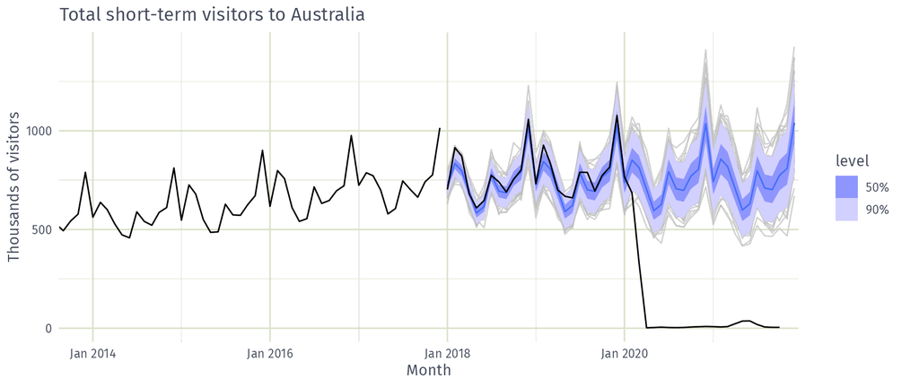

Simulated futures from an ETS model

## Was this a good forecast?

- Yes
- No

## What is a forecast?

A forecast is an estimate of the probability distribution of a variable to be observed in the future.

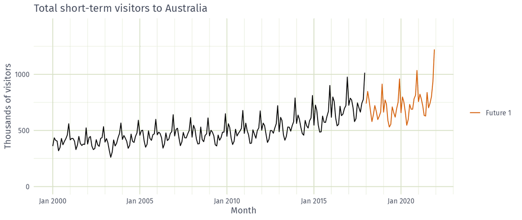

Simulated futures from an ETS model

## What is a forecast?

A forecast is an estimate of the probability distribution of a variable to be observed in the future.

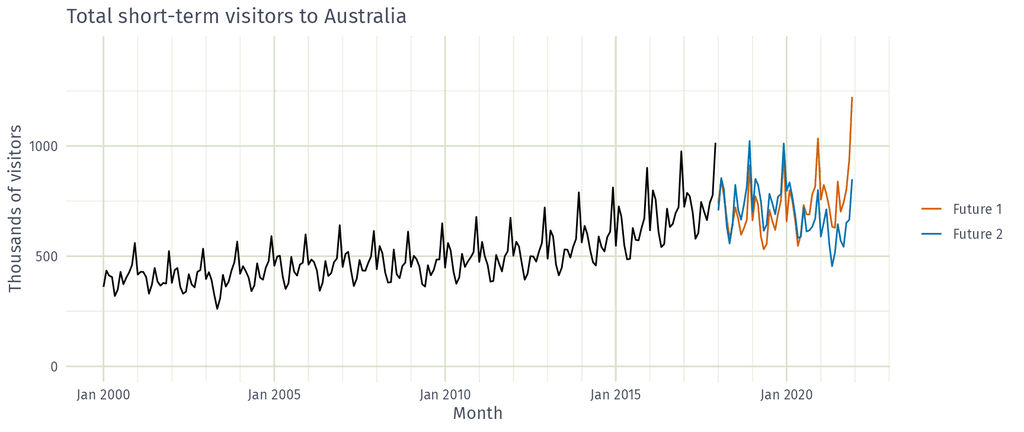

Simulated futures from an ETS model

## What is a forecast?

A forecast is an estimate of the probability distribution of a variable to be observed in the future.

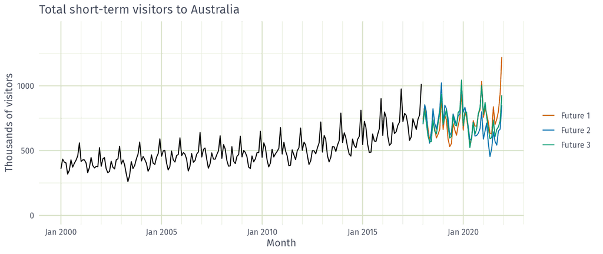

Simulated futures from an ETS model

## What is a forecast?

A forecast is an estimate of the probability distribution of a variable to be observed in the future.

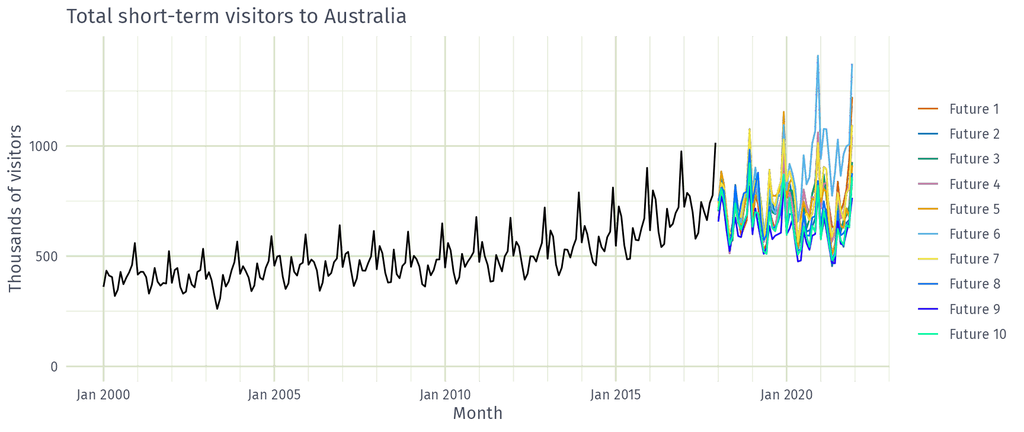

Simulated futures from an ETS model

## What is a forecast?

A forecast is an estimate of the probability distribution of a variable to be observed in the future.

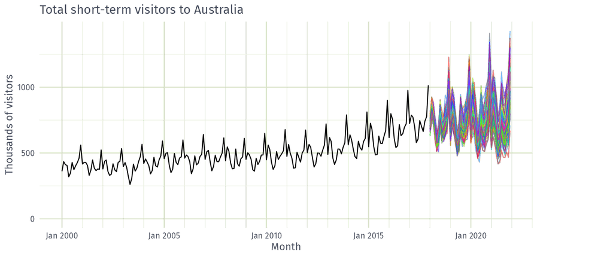

Simulated futures from an ETS model

## What is a forecast?

A forecast is an estimate of the probability distribution of a variable to be observed in the future.

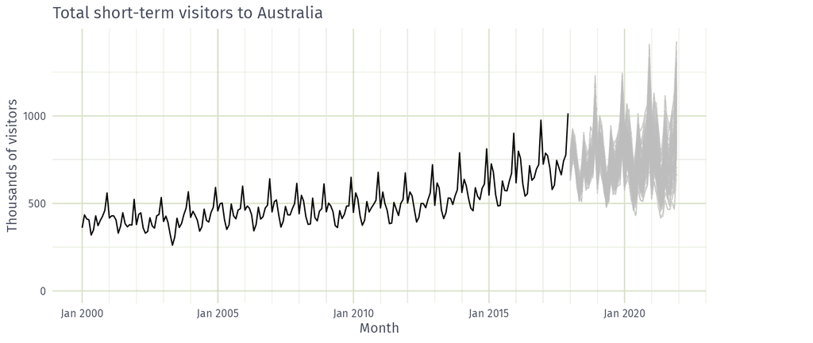

Simulated futures from an ETS model

## What is a forecast?

A forecast is an estimate of the probability distribution of a variable to be observed in the future.

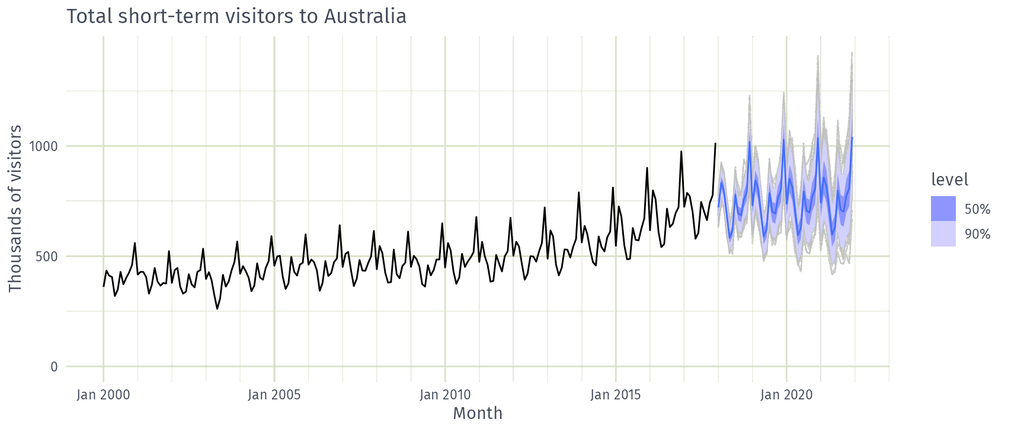

Simulated futures from an ETS model

## Prediction interval

A forecast is an estimate of the probability distribution of a variable to be observed in the future.

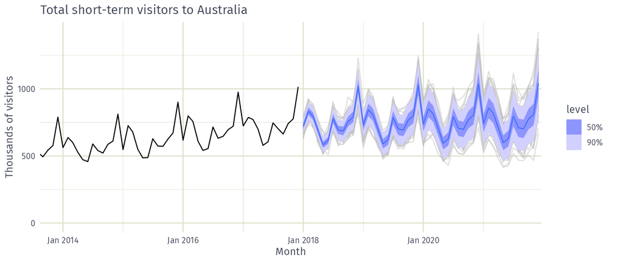

Simulated futures from an ETS model

## Visualising forecast distributions

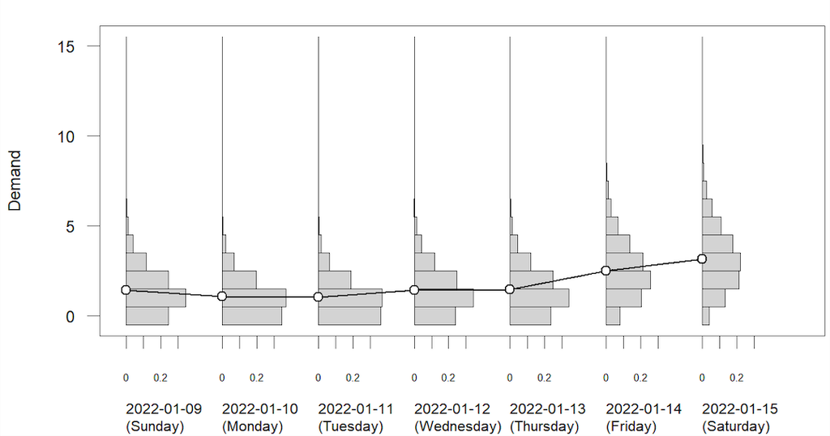

## Forecast distribution

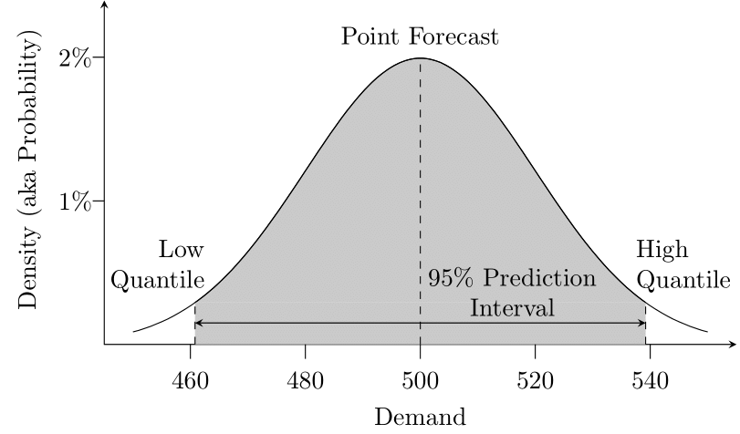

## Statistical forecasting

- Thing to be forecast: $y_{T+h}$.
- What we know: $y_1,\dots,y_T$.
- Forecast distribution: ${y}_{T+h|t} = y_{T+h} \mid \{y_1,y_2,\dots,y_{T}\}$.
- Point forecast: $\hat{y}_{T+h|T} =\text{E}[y_{T+h} \mid y_1,\dots,y_T]$.
- Forecast variance: $\text{Var}[y_{t} \mid y_1,\dots,y_T]$
- Prediction interval is a range of values of $y_{T+h}$ with high probability.

# What can we forecast?

## What can we forecast?

[figure not shown]

## What can we forecast?

[figure not shown]

## What can we forecast?

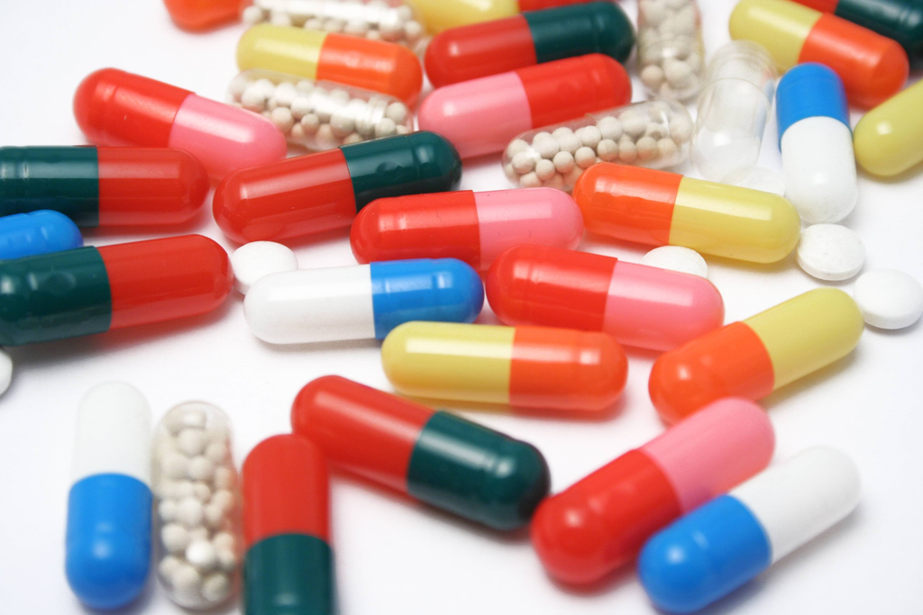

## What can we forecast?

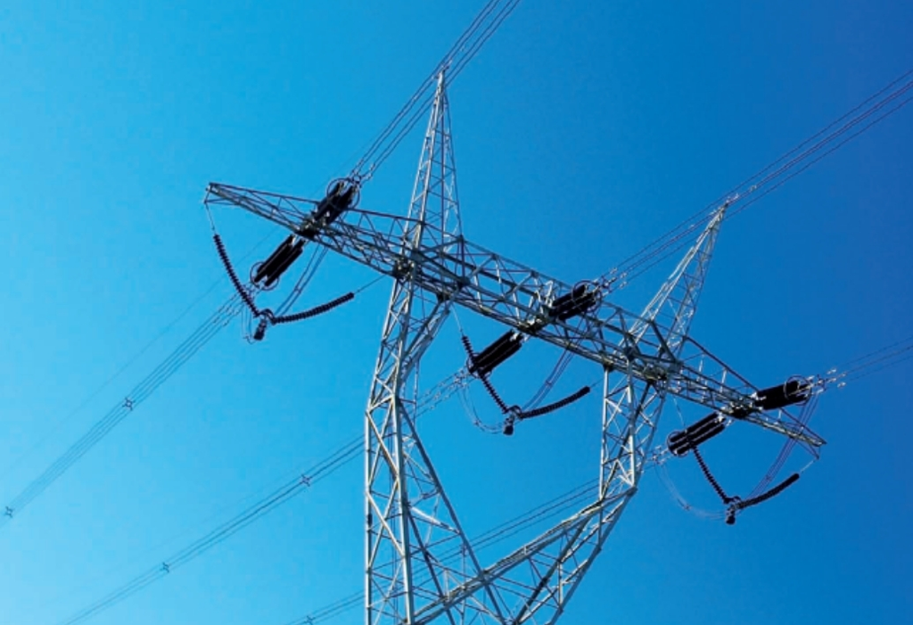

## What can we forecast?

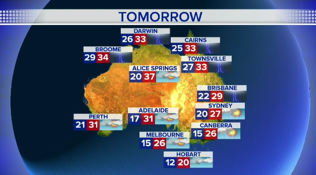

## What can we forecast?

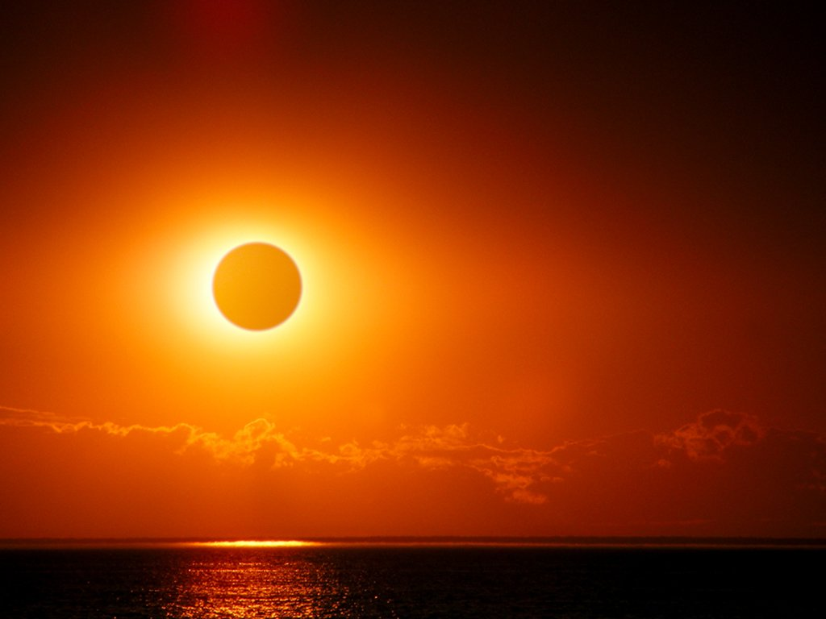

## What can we forecast?

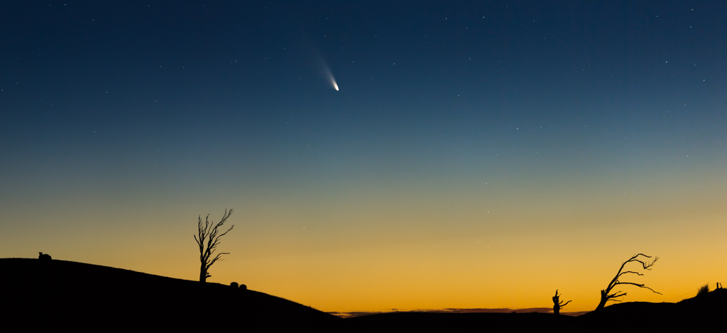

## Which is easiest to forecast?

- daily electricity demand in 3 days time
- timing of next Halley’s comet appearance
- time of sunrise this day next year
- Google stock price tomorrow
- Google stock price in 6 months time
- maximum temperature tomorrow
- exchange rate of $US/AUS next week
- total sales of drugs in Australian pharmacies next month

## Which is hardest to forecast?

- daily electricity demand in 3 days time
- timing of next Halley’s comet appearance
- time of sunrise this day next year
- Google stock price tomorrow
- Google stock price in 6 months time
- maximum temperature tomorrow
- exchange rate of $US/AUS next week
- total sales of drugs in Australian pharmacies next month

## Factors affecting forecastability

Something is easier to forecast if:

- we have a good understanding of the factors that contribute to it
- there is lots of data available;
- the forecasts cannot affect the thing we are trying to forecast.
- there is relatively low natural/unexplainable random variation.
- the future is somewhat similar to the past

# Benchmark methods

## Some simple forecasting methods

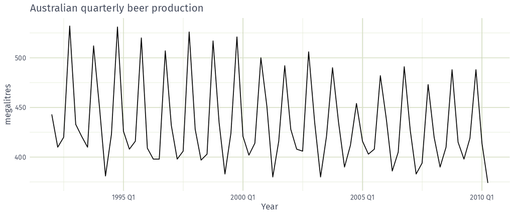

How would you forecast these series?

## Some simple forecasting methods

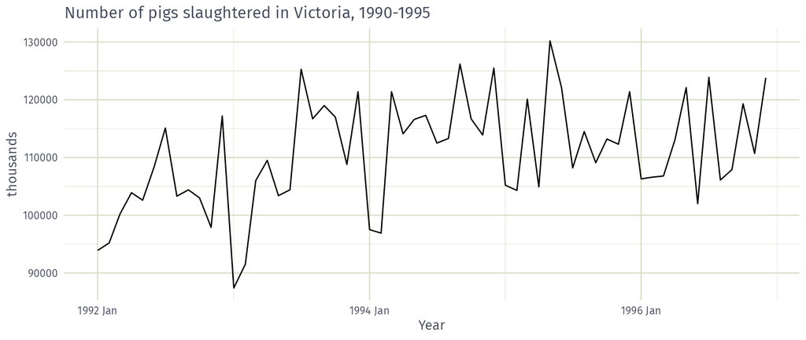

How would you forecast these series?

## Some simple forecasting methods

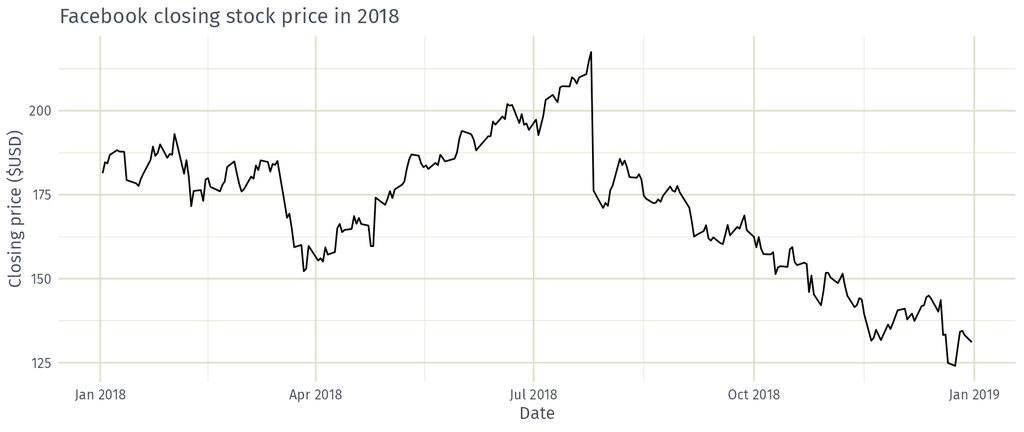

How would you forecast these series?

## Some simple forecasting methods

### `MEAN(y)`: Average method

- Forecast of all future values is equal to mean of historical data $\{y_1,\dots,y_T\}$.
- Forecasts: $\hat{y}_{T+h|T} = \bar{y} = (y_1+\dots+y_T)/T$

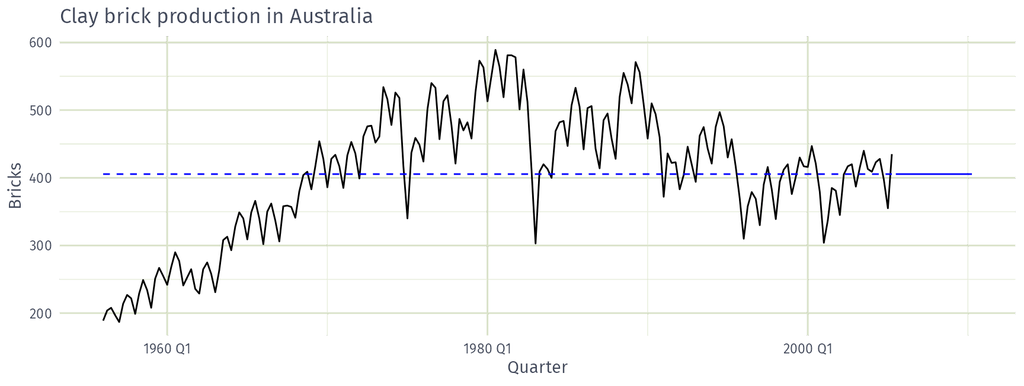

## Some simple forecasting methods

### `NAIVE(y)`: Naïve method

- Forecasts equal to last observed value.
- Forecasts: $\hat{y}_{T+h|T} =y_T$.
- Consequence of efficient market hypothesis.

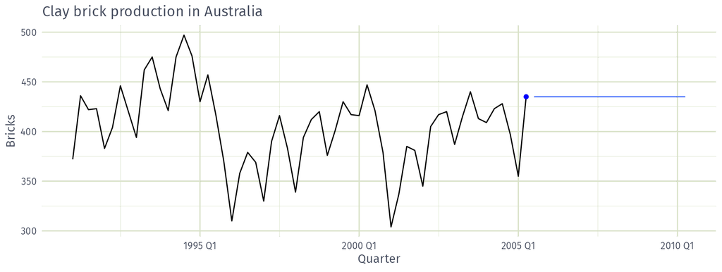

## Some simple forecasting methods

### `SNAIVE(y ~ lag(m))`: Seasonal naïve method

- Forecasts equal to last value from same season.
- Forecasts: $\hat{y}_{T+h|T} =y_{T+h-m(k+1)}$, where $m=$ seasonal period and $k$ is the integer part of $(h-1)/m$.

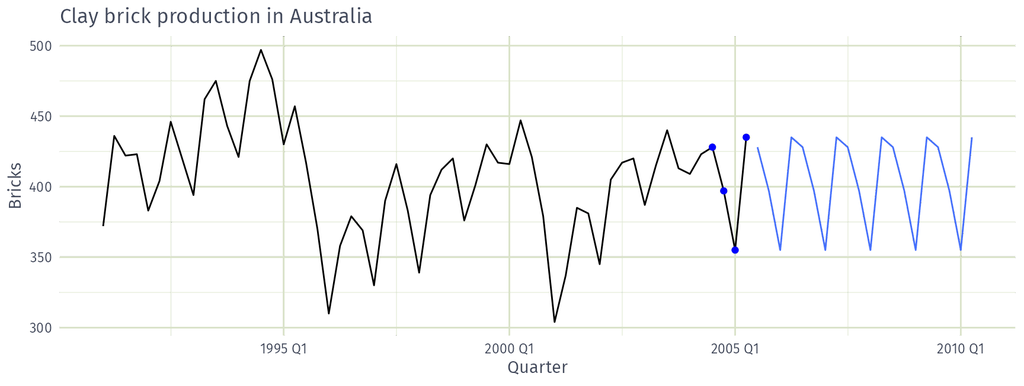

## Some simple forecasting methods

### `RW(y ~ drift())`: Drift method

- Forecasts equal to last value plus average change.
- Forecasts:

$$\begin{aligned}
\hat{y}_{T+h|T} & = y_{T} + \frac{h}{T-1}\sum_{t=2}^T (y_t-y_{t-1})\\
& = y_T + \frac{h}{T-1}(y_T -y_1).
\end{aligned}$$

- Equivalent to extrapolating a line drawn between first and last observations.

## Some simple forecasting methods

### Drift method

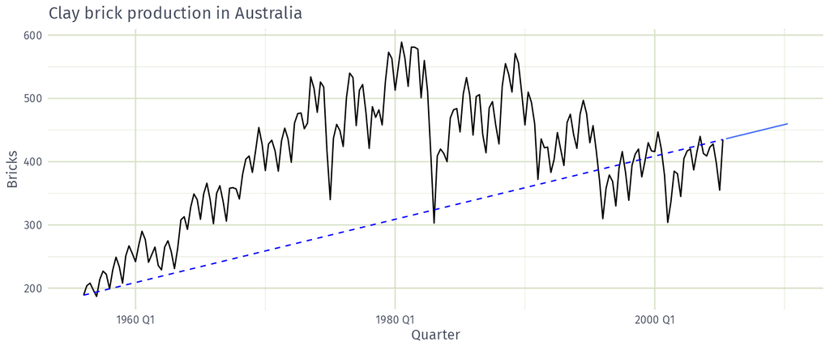

## Which benchmark suits the pigs series?

Which benchmark method is best for the number of pigs slaughtered in Victoria?

- `MEAN()`
- `NAIVE()`
- `SNAIVE()`
- `RW(~ drift())`